# Problem Set 3

Christen Parzych

9/2/2019

I used the same attrition dataset that was used during week 3’s async (at). I set my working directory and then loaded all of packages and the dataset itself:

```r
load("attrition.Rdata")
view(at)
```

##Question 1: Create a graph that shows the distribution of monthly income.

I chose to use a univariate histogram to display the distribution of monthly income. I chose the histogram in order to display the continuous variable (monthly income) across different ranges. I first pointed it to the correct dataset (at), defined the variable (MonthlyIncome), and plotted the histogram using ggplot. I set the bin width to 500 to determine the range on the x axis. This is a right-skewed distribution, with most employees making less than $5,000 a month.

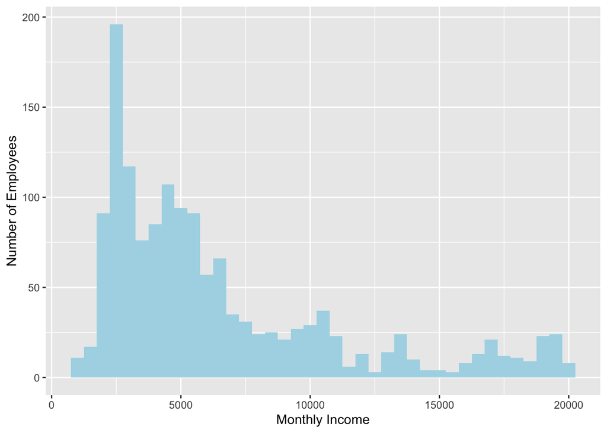

```r
gg<-ggplot(at,aes(x=MonthlyIncome))
gg<-gg+geom_histogram(binwidth = 500,fill="lightblue")
gg<-gg+xlab("Monthly Income")+ylab("Number of Employees")
gg
```

##Question 2: Create a graph that shows the average level of monthly income by field of education.

I chose to utilize a bar chart for this question, to show the average level of income by field of education. The variables are ‘MonthlyIncome’ and ‘EducationField.’ Each bar represents a different field of education.

First I made a prediction regarding average level of income by education field. I then created a new command called ‘inc_avg,’ which is equal to mean monthly income grouped by education field:

```r
at_sum<-at%>%
  group_by(EducationField)%>%
  summarize(inc_avg=mean(MonthlyIncome))


at_sum
```

```
## # A tibble: 6 x 2
##   EducationField   inc_avg
##   <chr>              <dbl>
## 1 Human Resources    7241.
## 2 Life Sciences      6463.
## 3 Marketing          7349.
## 4 Medical            6510.
## 5 Other              6072.
## 6 Technical Degree   5758.
```

I am going to use the summary data above (at_sum) to plot this in a bar graph. I set the statistic to ‘identity’ so that it plots what is in the dataset.

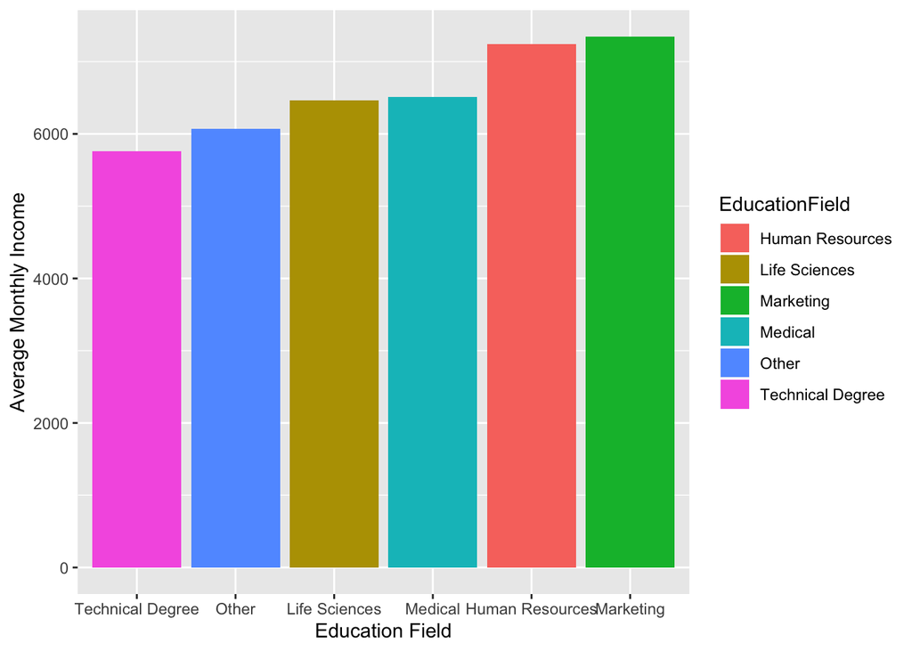

```r
## Plot it using a bar plot
gg<-ggplot(at_sum,aes(x=fct_reorder(EducationField,inc_avg),y=inc_avg))
gg<-gg+geom_bar(stat="identity",aes(fill=EducationField),position="dodge")
gg1<-gg+ylab("Average Monthly Income")+xlab("Education Field")
gg1
```

Individuals with degrees in human resources and marketing make the most in monthly income on average.

##Question 3: Create another graph that shows average level of monthly income by field of education and gender.

First I made a prediction regarding average level of income by education field and gender. I then created a new command called ‘inc_avg,’ which is equal to mean monthly income grouped by education field and gender.

```r
at_sum1<-at%>%
  group_by(EducationField,Gender)%>%
   summarize(inc_avg=mean(MonthlyIncome))%>%
  arrange(-inc_avg)



## Get the results
at_sum1
```

```
## # A tibble: 12 x 3
## # Groups:   EducationField [6]
##    EducationField   Gender inc_avg
##    <chr>            <chr>    <dbl>
##  1 Human Resources  Female   9568.
##  2 Marketing        Female   7586.
##  3 Marketing        Male     7167.
##  4 Technical Degree Female   7148.
##  5 Medical          Female   6520.
##  6 Medical          Male     6503.
##  7 Life Sciences    Male     6483.
##  8 Life Sciences    Female   6433.
##  9 Human Resources  Male     6262.
## 10 Other            Female   6114.
## 11 Other            Male     6048.
## 12 Technical Degree Male     4855.
```

I ran a similar bar plot but added an additional grouping variable (gender). I am going to use the summary data above (at_sum1) to plot this in a bar graph. I set the statistic to ‘identity’ so that it plots what is in the dataset. Gender is illustrated in the graph through the use of color. x (education field) and y (average monthly income) remain the same.

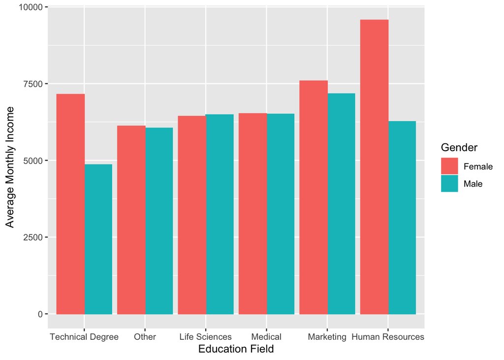

```r
## Plot it using a bar plot
gg<-ggplot(at_sum1,aes(x=fct_reorder(EducationField,inc_avg),y=inc_avg,color=Gender))
gg<-gg+geom_bar(stat="identity",aes(fill=Gender),position="dodge")
gg2<-gg+ylab("Average Monthly Income")+xlab("Education Field")
gg2
```

Women with technical or human resources degrees collect more salary in a month than men with degrees in the same education field.

##Question 4: Create a graph that shows average levels of monthly income by field of education, gender, and job level.

First I made a prediction regarding average level of monthly income by education field, gender, and job level ranking. As noted in the problem set instructions, the highest ranked employees are rated ‘5.’ I then created a new command called ‘inc_avg,’ which is equal to mean monthly income grouped by education field, gender, and job level rating.

```r
at_sum2<-at%>%
  group_by(EducationField,Gender,JobLevel)%>%
  summarize(inc_avg=mean(MonthlyIncome))%>%
  arrange(-inc_avg)

at_sum2
```

```
## # A tibble: 58 x 4
## # Groups:   EducationField, Gender [12]
##    EducationField   Gender JobLevel inc_avg
##    <chr>            <chr>     <int>   <dbl>
##  1 Technical Degree Female        5  19744
##  2 Other            Male          5  19443.
##  3 Human Resources  Male          5  19322
##  4 Medical          Male          5  19251.
##  5 Technical Degree Male          5  19232
##  6 Life Sciences    Male          5  19232.
##  7 Life Sciences    Female        5  19143
##  8 Marketing        Female        5  19101.
##  9 Other            Female        5  19094
## 10 Medical          Female        5  19032.
## # … with 48 more rows
```

This time I ran sub-bar-plots by using the facet option to display all of the variables being graphed. I used the summary data above (at_sum2) to plot this in multiple bar graphs. I again set the statistic to ‘identity’ so that it plots what is in the dataset. I originally ran these bar graphs vertically, but I decided to flip them in order to read them a bit easier. Although these graphs display a lot of information, they do not make the most effective visual.

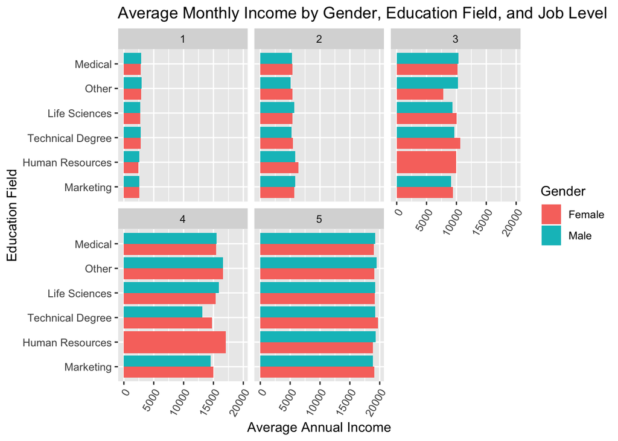

```r
gg<-ggplot(at_sum2,aes(x=reorder(EducationField,inc_avg),
                      y=inc_avg,
                      fill=Gender))
## Bar plot, with unstacked (dodge)
 gg<-gg+geom_bar(stat="identity",position="dodge")
## Separate out by Marital Status
gg<-gg+facet_wrap(~JobLevel)

gg<-gg+ylab("Average Annual Income")+xlab("Education Field")
gg<-gg+theme(axis.text.x = element_text(angle = 60, hjust = 1))
gg<-gg+coord_flip()
gg3<-gg+ggtitle("Average Monthly Income by Gender, Education Field, and Job Level")
## Print
gg3
```